# Salikšanas spēles (Assembly puzzles)

# Salikšanas spēļu prakse: 8 N-tetrakubi

Spēles aprakstu 2003.gadā izveidoja Andrejs Cibulis (Andrejs.Cibulis@lu.lv). Sākotnējais izplatītājs - SAF “Arnika un partneri” (Rīga, tel. +371 66748248). Spēli veido astoņas vienādas detaļas. Katra detaļa ir “tetrakubs” - no 4 vienādiem kubiņiem salikta figūriņa, kas atgādina lielo “N” burtu.

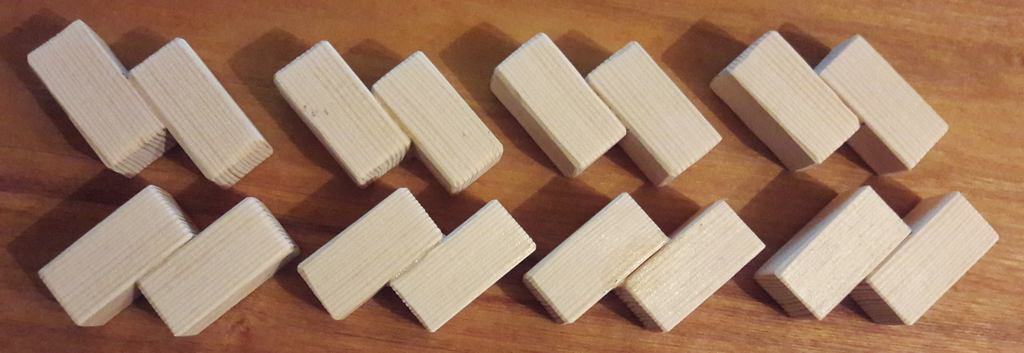

2. attēls: N-tetrakubu komplekts

## Spēle 8 N-tetrakubi: Teksta uzdevumi

Šajā sadaļā apkopojam “teksta uzdevumus”, kas izmanto 8 N-tetrakubus.

**1. uzdevums:** Salikt attēloto simetrisko torni.

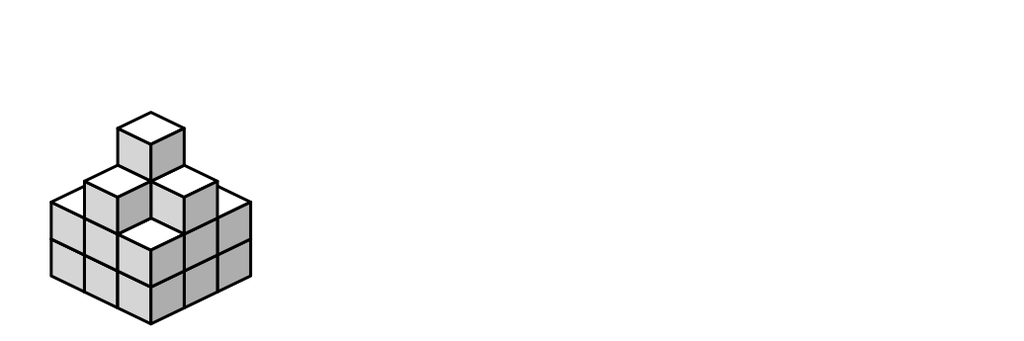

**2. uzdevums:** Zīmējumā parādīts stabils tornis (tāds, kas negāžas) ar augstumu 4 “rūtiņas”. Salikt no 2 detaļām augstāku torni, kura augstums joprojām ir vesels skaits rūtiņu.

[figure not shown]

**3. uzdevums:** Salikt no 2 detaļām vēl augstāku torni nekā iepriekšējā uzdevumā.

**4. uzdevums:** No 4 detaļām izveidot *plakanu* (1 ``rūtiņu’’ augstu) figūru, kurai ir 4 simetrijas asis.

**6. uzdevums:** Parādīt, kā ar 6 detaļām var ierobežot 6 izolētus kvadrātiņus.

**8. uzdevums:** Izvietot 6 detaļas kastītē $3 \times 3 \times 3$.

**9. uzdevums:** No 5 detaļām izveidot kādu jaunu simetrisku figūru, kuru var izvietot kastītē $3 \times 3 \times 3$. (Esošās figūras sk. zemāk sadaļā “No 5 figūrām”).

## Salikt attēlotās figūras

### No 2 detaļām

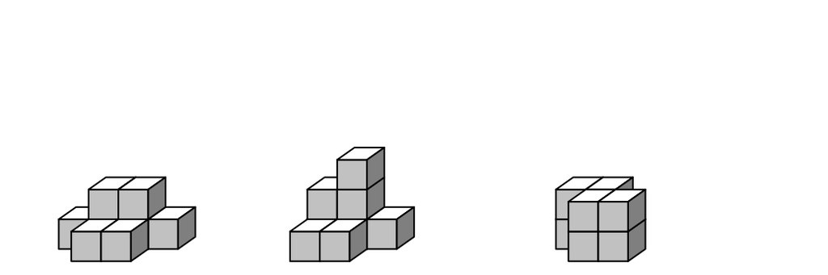

### No 3 detaļām

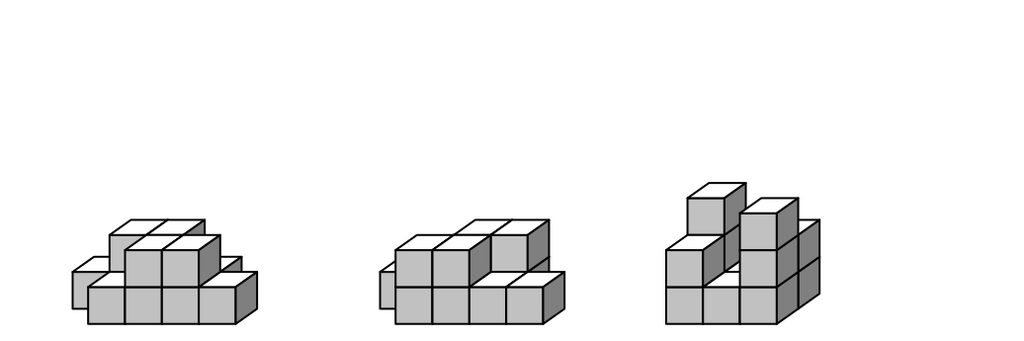

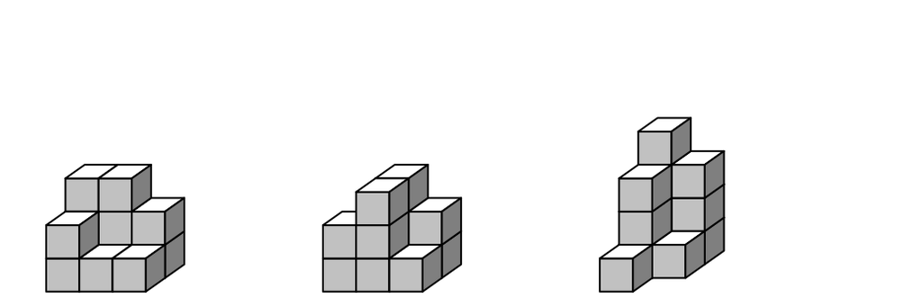

### No 4 detaļām

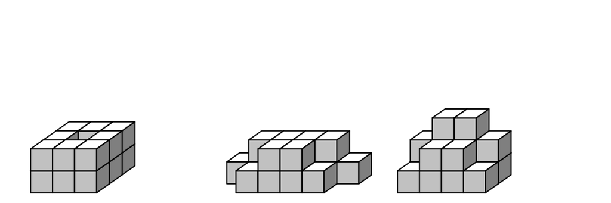

### No 5 detaļām

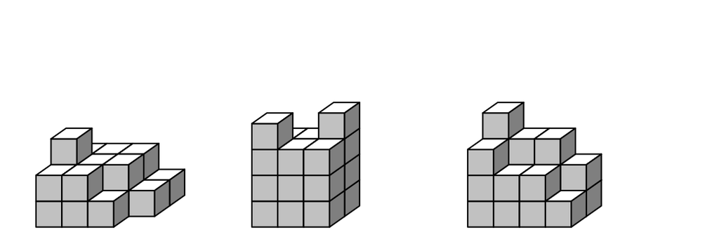

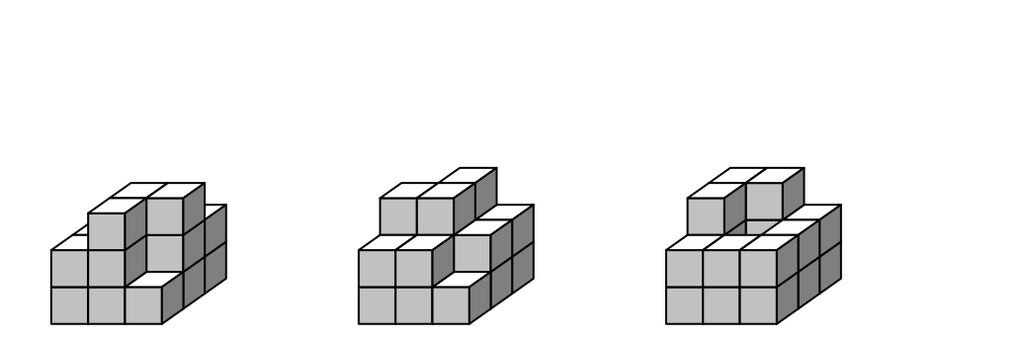

### No 6 detaļām

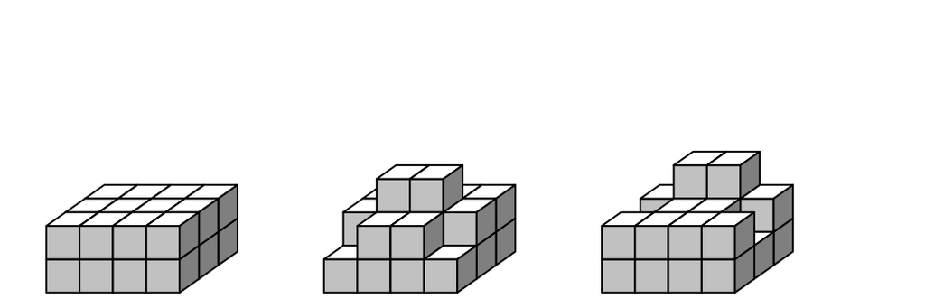

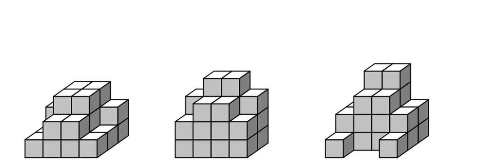

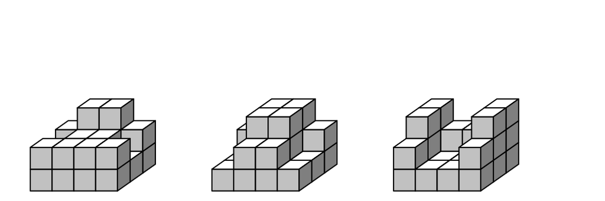

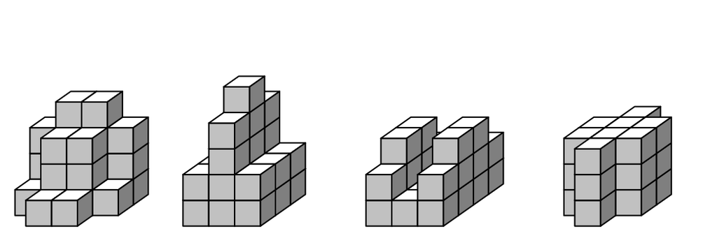

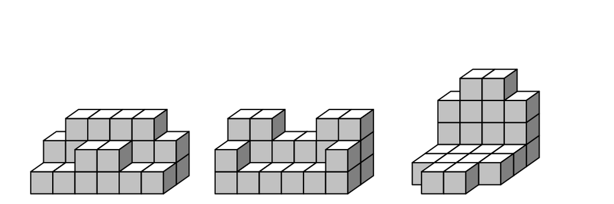

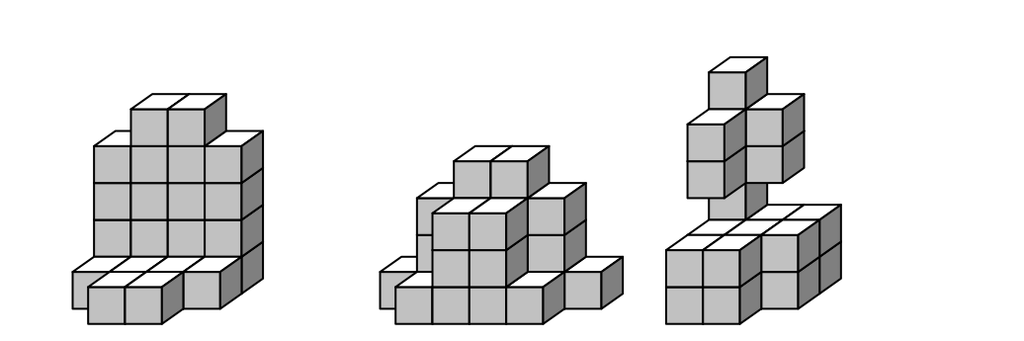

## No 7 detaļām

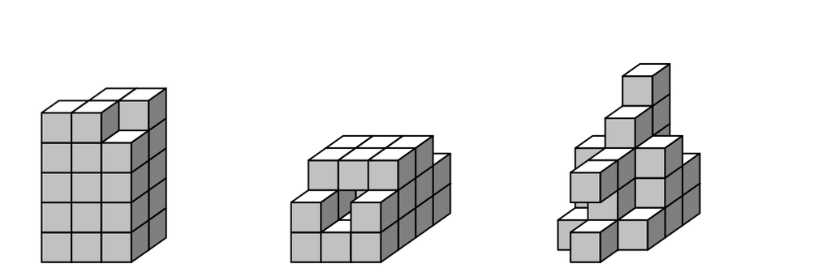

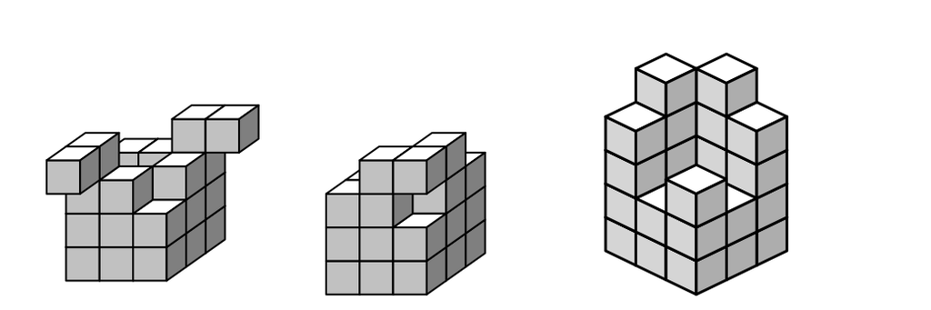

### No 8 detaļām

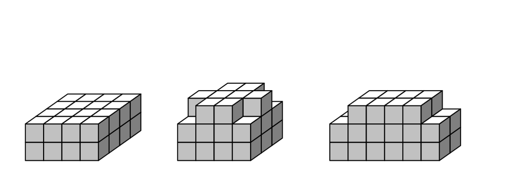

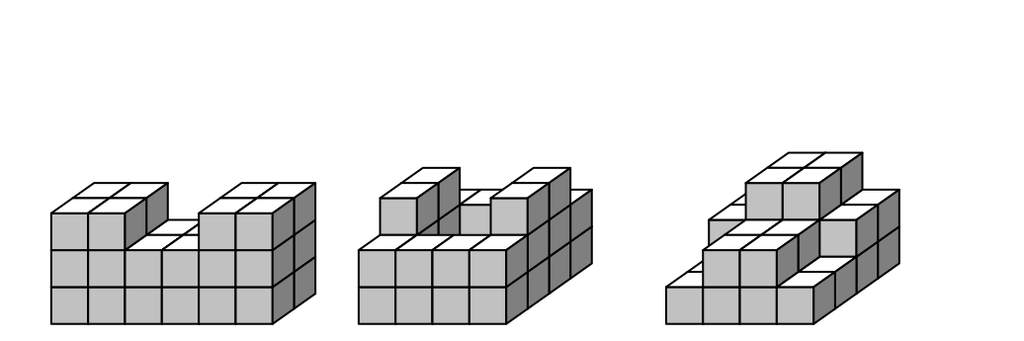

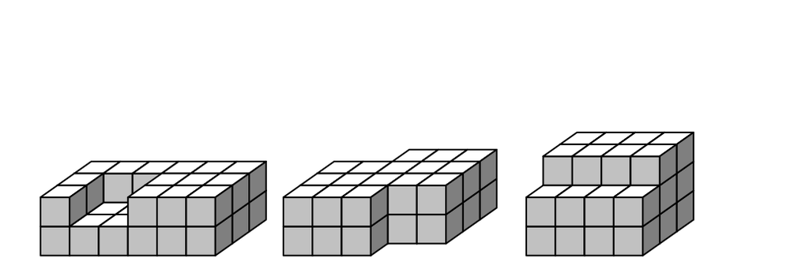

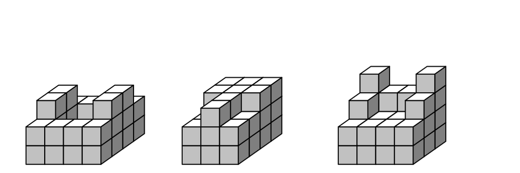

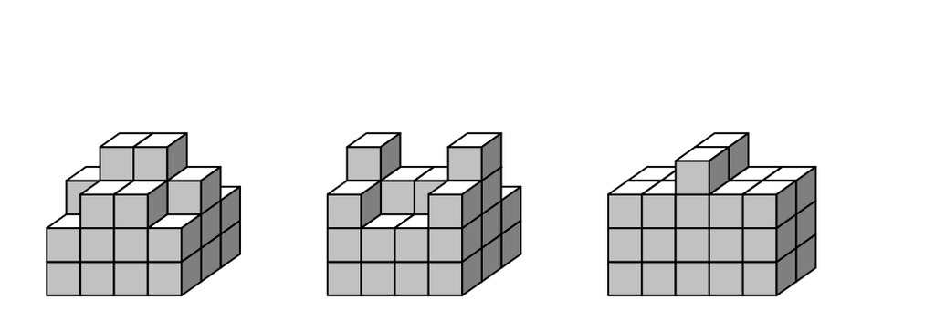

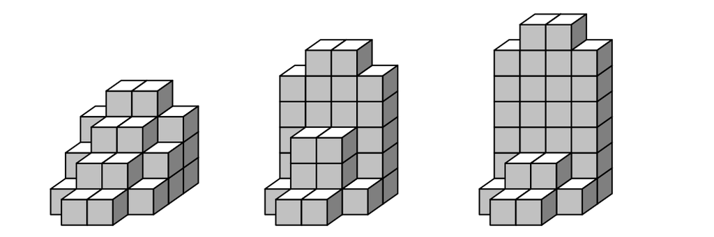

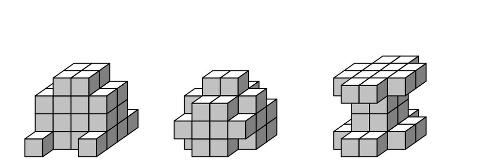

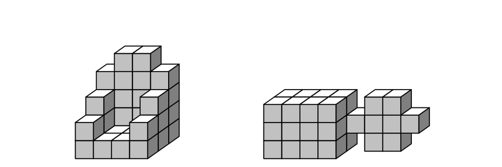

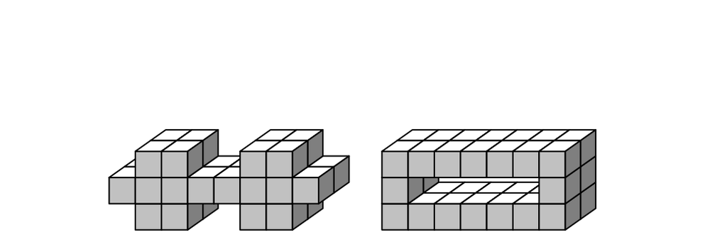

## Atrisinājumi

**1. uzdevums:** Šis ir viens no sarežģītākajiem piemēriem; ir jāaplūko dažādi pieņēmumi par torņa kopskatā neredzamajām rūtiņām.

**2. uzdevums:** Daudziem risinātājiem šķiet, ka risinājums jāmeklē sabīdot kubiņus cieši kopā. Tad stabili nolikt figūriņu neizdodas, jo N-tetramino, ja to noliek “uz gala”, gāžas uz sāniem (masas centrs atrodas N-tetramino pašā vidū un viegli pārveļas pāri atbalsta kvadrātam). Toties pietiek nedaudz pabīdīt augšējo N-tetramino uz sāniem, lai rastos stabila figūra (tiesa, ar caurumu vidū).

**3. uzdevums:** Šoreiz ir vēl tālāk jāatkāpjas no “standarta” domāšanas paradumiem - augšējo figūriņu attiecībā pret apakšējo jānovieto grūti nosakāmā leņķī, lai tā nenoslīdētu ne uz vienu, ne uz otru pusi. Pamatojaums, kādēļ šī figūra ir augstāka par 5 rūtiņām, izietu ārpus jaunāko klašu kursa (tas ir vidusskolas uzdevums, kas prasa arī fizikas zināšanas - kā atrast stabilu stāvokli augšējai detaļai). Tomēr praksē var pārliecināties, ka šāda figūriņa ir nedaudz augstāka par iepriekšējā uzdevumā aplūkoto.

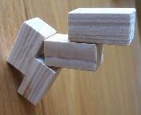

6. attēls: Konstrukcija augstāka par 5 kubiņiem

### No 2 detaļām

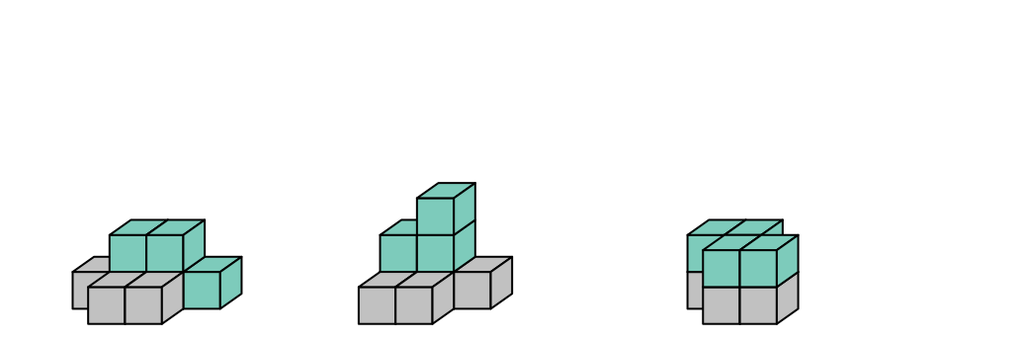

### No 3 detaļām

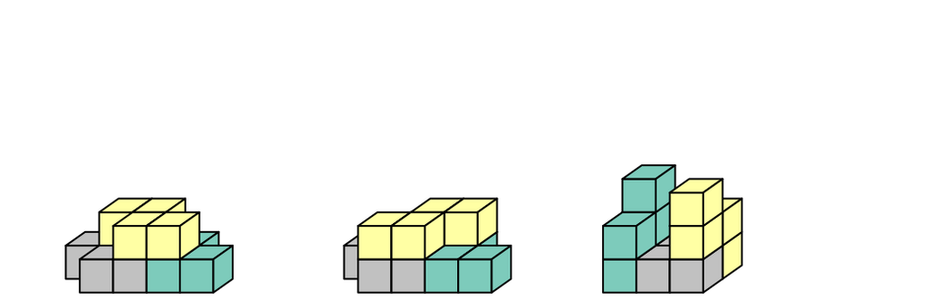

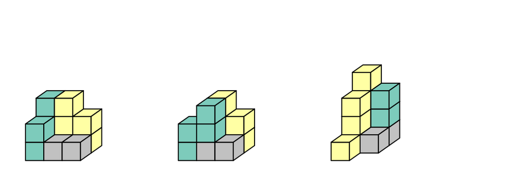